# Socioeconomic status and Democratization

# Abstract

This paper examines the effects of socioeconomic status on democratization. The research is conducted on the basis of the data from different sources, such as the World Bank, the United Nations, and the Polity Project, with three selected countries: South Africa, Botswana, and Kenya. Using OLS and panel data regression models, we find evidence that GDP per capita is not statistically significant on democratization, while Child mortality rate under 5 and Primary education enrollment rate are having strong explanatory power on the level of democracy. Interestingly, however, we also find that gender equality has rather negative effect on democracy.

# Introduction

The dictionary meaning of “Democracy” defined by Encyclopedia Britannica is “literally ruled by the people.” As we all learned from social science classes, democracy is derived from the Greek words “coined from demos -people- and kratos -rule- in the middle of the 5th century BC to denote the political systems” in Athens. In modern usage, democracy often refers to a system of government where the citizens exercise power directly or through electing representatives in order to form a parliament. Thus, it is to be distinguished from monarchy or dictatorship. Yet, there is no consensus on how to define democracy while some of characteristics such as political freedom, rule of law, and equality before the law are commonly seen and identified as basic features of democracy.

Measuring democracy also has been contested that there still have ongoing debates on this subject. The most widely-known measure is from the US-based Freedom House organization, which aggregates scores of 25 indicators up to 100, on a 1 to 7 rating scale, from political rights and civil liberties. Another organization where also provides measures of democracy and regime types is The Polity Project. Specifically focused on the institutionalized authority patterns of the state regime, The Polity Project “examines concomitant qualities of democratic and autocratic authority in governing institutions […to] envision a spectrum of governing authority that spans from fully institutionalized autocracies through mixed, or incoherent, authority regimes to fully institutionalized democracies (Center for Systemic Peace) based on”The Polity conceptual scheme." For our current research, this Polity data from the Polity Project is used. Capturing such regime authority spectrum on 21 point scale from -10 (hereditary monarchy) to +10 (consolidated democracy), “The Polity Scores” are categorized into autocracies, anocracies, and democracies.

Following the introduction, this research paper will proceed by presenting background researches about democratization and its history in Africa to set up the baseline and link to our research question and hypotheses at the following section. After that, details about data, variable selections, and overall statistical methods will be addressed along with explanations how the authors collected, cleaned, and utilized each data. Based on the cleaned data, the authors will provide descriptive analyses as a preliminary stage, and then the multivariate analyses conducted based on the various statistical models will be interpreted by concentrating on the effects of four socio-economic variables on democratization in three selected African countries.

# Background about Democratization and its brief history in Africa

Democratization, according to An Agenda for Democratization by Boutros Boutros-Ghali, the formal Secretary General of the United Nations, “is a process which leads to a more open, more participatory, less authoritarian society” (1) within a sovereign state. Between the years 1974 and 1990, the world experienced “Third Wave” of democratization which had changed 30 countries from authoritarian regimes to democracies. From his On Democracy, Robert Dahl suggests three conditions that are essential to attain democratic institutions through democratization and they are: control over military and police forces by elected officials; the absence of foreign intervention opposing democratization; democratic beliefs and political culture; [possibly] modern market economy and economic growth; and the absence of cultural pluralism. Similarly, Samuel Huntington, from his book The Third Wave, argues that democracy could be realized through one of three main types of democratization process and they are: transformation led primarily by the ruling elites; replacement where the opposition plays the main role; and transplacement, a product of active engagement of both sides. With looking into these arguments, it can be claimed that there is no single precondition or factor which perfectly lead the country to be democratized. It has to be a combination of features which should be uniquely and country specifically taken since the strength of each factor may bring different impacts to country by country.

Africa has also been the wave of political transitions from various types of dictatorships to more open political systems by accepting democracy as a political alternative. However, to understand the democracy and the democratization in Africa, its background of “the relatively recent end to colonial rule, post-colonial utopian African socialism, and economic regression in the 1980s” (Samarasinghe, 1994) has to be taken into account. Even after the independence, the artificiality of Africa’s national borders and of the societies within worsened the problem and prevented the transition to democracy. During the first half of 1990s, many African countries had one party and military rule which were followed by political protests and competitive elections with democratic trend indicators continuing to rise. Although the surge of democratic trends with the liberalized political system swept across African countries during this time period, they could not proceed to the full democracy. The repetition of the onset of democratization and frequent slips back to authoritarianism took place in Africa due to a set of existing political structures which had been governed through coercion and a lack of institutional capacity for the provision of basic services and law and order. In spite of all these negative factors, many of African countries has been constantly making progress towards the democracy not only by revolting against authoritarian leaders but also by the improvement of other numerous socio-economic indicators which may influence the political transformation.

# Research Question and Hypotheses

The current research aims to help our understanding of the democracy with regard to its concept structure by investigating the effects of various socio-economic variables on democratization in African countries. Therefore, our research question is to assess how four important socioeconomic variables, namely income growth, primary education enrollment, gender equality in labor force, and child mortality, affect the regime change to democracy and the consolidation of democratic institutions through sustaining the process of democratization.

Sub-Saharan African countries, where continuously have been experiencing democratic progress and setbacks due to frequent violence triggered by political conflicts in spite of their future development potentials, are still more democratic today than in any other periods of time. From the authors’ academic interests as well as sincere hope for more meaningful processes towards democratic development, African countries are selected to be studied, compared, and tested for the current research study. In order to effectively analyze and answer to the research question, following three hypotheses are set up to be tested:

1. There is a significant and positive correlation between socioeconomic variables and democracy.
2. Among four socioeconomic variables - GDP, primary education enrollment, gender equality, and child mortality - the educational effect on democracy is the strongest among any other variables.
3. The degree of impact of variables on democracy is consistent across selected African countries.

# Literature Review

With regard to measuring democracy, Robert J. Barro (see Barro (1999)), for his paper Determinants of Democracy, used the indicator of electoral rights compiled by Gastil and his followers at Freedom House from 1972 to 1995. He observed the sub-Saharan African’s decline in electoral rights after 1960 and back to rise in 1995. According to his argument, “many of African countries [experienced the pattern of fluctuation because they] began with ostensibly democratic institutions when they became independent in the early 1960s, but most evolved into one-party dictatorships by the early 1970s,” and also the democratization in Africa since 1989 was substantial. Although the authors of this current research paper used different data to measure democracy, sub-Saharan African’s fluctuations in democracy are also observed, implying that there are some drivers that affect the level of democracy overtime.

Further, Barro (see Barro (1999)) quotes Lipset’s argument based on the Lipset hypothesis, which claims that increased education and an enlarged middle class are key elements for the extent of democracy, as in general increases in various measures of the standard of living forecast a gradual rise in democracy. To test this, Barro ran the basic regression for electoral rights -democracy- with the explanatory variables. According to his data results, the schooling figures that turn out to have the most explanatory power are the average years of attainment at the primary level for persons aged 25. In regard to the correlation between GPD and democracy, Barro claims that more prosperous places are more likely to be democratic, displaying positive upward trends between per capita GDP and schooling to democracy.

In the second literature of Democracy and Gender Equality by Caroline Beer (see Beer (2009)), she conducted this study in the basis of a generally accepted assumption - also one of our hypotheses- that democracy and gender equality go hand in hand, therefore, democracy promotes the well-being of women. In her previous studies, Beer quotes Richard and Gelleny’s research Women’s status and economic globalization, which measure the status of women with the United Nations Gender-related Development Index (GDI) and Gender Empowerment Index (GEM) and find the positive relationship between democracy and their indicators of women’s status. On the other hand, according to Fish from Beer’s study, gender equality causes democracy, suggesting the reverse causality (Islam and authoritarianism, 2002). Overall from Beer’s previous studies, there is not clear statistical evidence which demonstrate the effects of gender equality on democracy and vice versa. Measuring gender equality in terms of the percentage of the population that is female, the ratio of female life expectancy at birth to that of males, the percentage of the total labor force that is female, Beer however finds that, all else equal, long-term democracies tend to promote greater gender equality than authoritarian regimes.

John M. Shandra et al. approaches child mortality from different theoretical perspectives (see Shandra et al. (2005)). By taking political modernization perspective, he quotes from the previous studies that the level of political democracy influences the level of child mortality in developing countries, while Shandra et al. finds only one study which supports for the hypothesized inverse relationship between democracy and child mortality. Tanja AJ Houweling et al. in their Determinants of under-5 mortality among the poor and the rich: a cross-national analysis of 43 developing countries which studies how under-5 mortality rates vary with the national level context, they argue that more democratic and ethnically homogeneous countries show significantly lower total under-5 mortality rates in the univariate analysis (see Houweling (2005)). While there are poor-rich inequalities in childhood mortality, the research suggests that democracy has a role in reducing the inequalities. (see Boutros-Ghali (1996) R. Dahl (2000) R. A. Dahl (2010) (“FREEDOM in the World 2016” 2016) (n.d.) Kekic (2007) Samarasinghe (1994) Barro (1999) Beer (2009) Shandra et al. (2005) Houweling (2005) (“PolityProject,” n.d.) Exponent (2015) Bayanpourtehrani and Sylwester (2012))

# Data, Variables, and Methods

Among all other African countries, South Africa, Botswana, and Kenya are chosen to be compared for this research. This selection was done based on the World Economic Forum’s Global Competitiveness Report 2015-2016, which assesses the competitiveness of 140 world economies. With the emphasis of the region’s need to prioritize competitiveness and enhance reforms, the report ranked top 10 performers in the sub-Saharan region and the authors selected 3 countries according to their ranks on top, middle, and bottom; South Africa (49th), Botswana(71th) and Kenya (99th). The authors wanted to observe both similarities and differences on the relationship between socioeconomic variables and democracy across diversified countries in terms of economic performances and their competitiveness.

## Data collection

The analysis with regard to the relationship between socioeconomic status and democracy in this research is studied by using three different data sources. Also, in order to test three hypotheses, the authors selected four socioeconomic indicators as explanatory variables, while democracy being a dependent variable. The names, details and sources for those variables are shown in the chart below.

| Variable name | Detail | Source |
| --- | --- | --- |
| polity4 | measurement of democracy | the Center for systemic peace |
| gdppc | Gross Domestic Production Per Capita | World Bank |
| pe | Primary ed enrollment | United Nations |
| mr | Child Mortality under 5 | United Nations |
| gi | gender inequality in labor market | United Nations |

. Dependent Variable- Democracy: In the current research, Polity IV Project’s measurement of democracy is used. Polity IV represents the degree of democratization: when the democratization level is higher, the score is also high. The data can be downloaded from this site.

http://www.systemicpeace.org/inscrdata.html

. Explanatory Variable 1- GDP per capita: This data comes from the World Bank database. GDP per capita represents the level of standard living by indicating how prosperous a country feels to each of its citizens. The following URLs are WorldBank sites in which the data for the time-series of GDP for each country were downloaded.

http://data.worldbank.org/indicator/NY.GDP.PCAP.CD, http://data.worldbank.org/indicator/NY.GDP.PCAP.CD?locations=BW, http://data.worldbank.org/indicator/NY.GDP.PCAP.CD?locations=KE

. Explanatory Variable 2-Primary education enrollment: According to Lipset, higher levels of education instill democratic values as education broadens students’ outlooks by enabling them to understand the norms of democracy. Thus, primary education enrollment is included in this study from the expectation that it may generate supports for democracy in the African region. The following is the URL of the United Nations Database site in which the data was downloaded.

http://data.un.org/Data.aspx?q=education&d=UNESCO&f=series%3aE_1

. Explanatory Variable 3-Mortality rate under 5 years old: Under-5 mortality is associated with levels of public spending and health care; thus, this variable is included from the assumption that there is an association between welfare and the promotion of democracy. The following is the URL where the data came from.

http://data.un.org/Data.aspx?q=mortality&d=PopDiv&f=variableID%3a77

. Explanatory Variable 4-Gender Inequality in labor market: The measure of gender inequality in labor market is used to test whether the participation of women in workforce is related to democracy. The calculation of the unit as follows:

$$GenderInequality = \frac{EmploymentRateAmongWomen}{EmploymentRateAmongMen}$$

The data can be found from International Labor Organization (IL0) website.

http://www.ilo.org/ilostat/faces/help_home/data_by_subject/subject-details/indicator-details-by-subject?subject=EMP&indicator=EMP_2EMP_SEX_AGE_NB&datasetCode=YI&collectionCode=ILOEST&_afrLoop=201714902217437#!%40%40%3Findicator%3DEMP_2EMP_SEX_AGE_NB%26subject%3DEMP%26_afrLoop%3D201714902217437%26datasetCode%3DYI%26collectionCode%3DILOEST%26_adf.ctrl-state%3D102r3mzd68_271

## Data cleaning and importing into R

Each data set is downloaded with excel and csv file. Then, each variable and country are extracted for time-series data, which are put together into three csv files. They represent each country so that they can be easily imported into R. That means, there are three csv files that each represents South Africa, Botswana, and Kenya.

```r
dfsa <- read.csv("SA.csv", header = TRUE, sep = ",")
dfbo <- read.csv("BTW.csv", header = TRUE, sep = ",")
dfkn <- read.csv("KNY.csv", header = TRUE, sep = ",")
dfpanel <- read.csv("panel.csv", header = TRUE, sep = ",")
```

All files are successfully imported to R.

# Descriptive Analyses

## Democratization

Following graphs are the trends of democratization for each country.

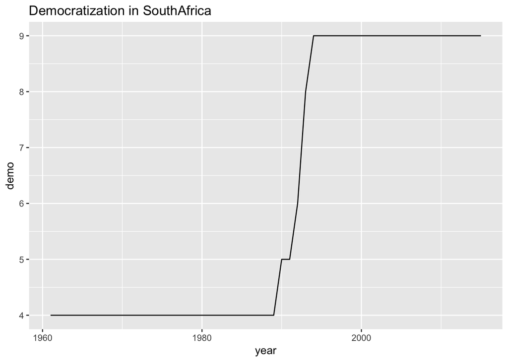

The above graph shows the trend of democratization in South Africa. As easily can be seen, the level of democracy dramatically spiked during the early 1990s, which implies the abolishment of Apartheid and the start of free election.

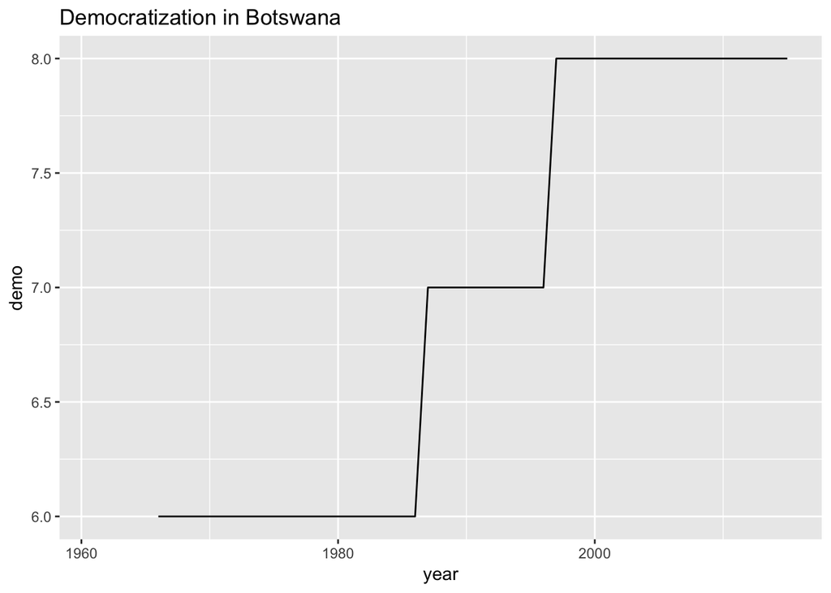

The graph of Botswana’s level of democratization reveals that there had two big leaps in the mid-1980s and the mid-1990s, and it has been stable since then. Compared to South Africa whose highest point is 9.0, Botswana’s highest level of democracy is 8.0 despite the fact that Botswana has been practicing democracy since its independence in 1965 and maintained multi-party democratic system for relatively longer periods than neighboring countries.

[interactive chart not shown]

# Multivariate Analyses

This section of the analyses will offer a look at the effect of socioeconomic factors on the degree of democratization and the comparison of each coefficient among countries through quantitative analysis method. Dividing the section into three parts, the authors will investigate country-specific coefficients for each variable in each country by using regression analysis in the first part. It will allow us to make clear comparisons among coefficients across countries. In the second part, the authors will employ the panel regression model in order to observe the general effect of each variable on the level of democratization. To achieve this purpose, several different models will be utilized so as to eliminate country-specific effects, to compare the results of each model, and to decide the most effective model among all others so that the authors could get unbiased and most efficient coefficients. In the final part, the overall results and answers to the hypotheses will be provided.

## 1. Regression analysis for each country

In this part, the OLS regression analysis is conducted with a following model:

$$polity4 = \beta_0 + \beta_1\log{gdppc}+\beta_2\log{pe}+\beta_3\log{mr}+\beta_4\log{gi} + \epsilon$$

Logarithm is used for each explanatory variable in order to compare the effect of each variable on the dependent variable. Because of the huge difference in scale between variables, logarithm has to be utilized. With the use of logarithm, all the variables are transformed into percentage changes, which allows easier comparisons in the same scale.

- In South Africa, gdppc has a negative effect on the degree of democratization, while gdppc has a positive effect in Botswana. In Kenya, gdppc is not even statistically significant. This means that the effectiveness of GDP per capita on the degree of democracy is different across countries.
- Primary education enrollment is statistically not significant in all countries. Such result seems contradictory to the previous researches, which find that the education level is significant for democracy.
- Mortality rate under 5 years old shows inconsistencies like gdppc. This variable is significant in Botswana and Kenya, and its effect on the degree of democracy in Botswana is positive while it is negative in Kenya. If the effect is positive, it means that higher number of mortality increases the level democracy. On the other hand, having a negative effect means that as the number of child mortality increases, the democracy will setback.
- Gender inequality shows consistencies in South Africa and Kenya. In both countries, the variable is significant and has negative effect on the degree of democracy. The negative effect means that if the female labor force participation rate increases, the level of democracy gets deteriorated. While this negative effect contradicts our common assumption, Ghazal Bayanpourtehrani and Kevin Sylwester also find that Female Labor Force Participation decreases in democracies, implying that democracy is not associated with higher female employment.Some of possible explanations for this finding are first, autocrats may direct more labor from both genders into the formal workforce to raise aggregate output for political propaganda (Bayanpourtehrani et al., 750). Also, agricultural societies in non-democratic countries may have higher rate of female employment compared to industrialized democratic countries because agricultural activities tend to require higher amount of female labor participation.

## 2. Regression Analysis on panel data

In this section, the regression model on panel data, which includes time-series data for every country, is applied to investigate the overall effect of each explanatory variable. Firstly, the pooled OLS regression is employed based on the following regression equation:

$$polity4 = \beta_0 + \beta_1\log{gdppc}+\beta_2\log{pe}+\beta_3\log{mr}+\beta_4\log{gi}+ \epsilon$$

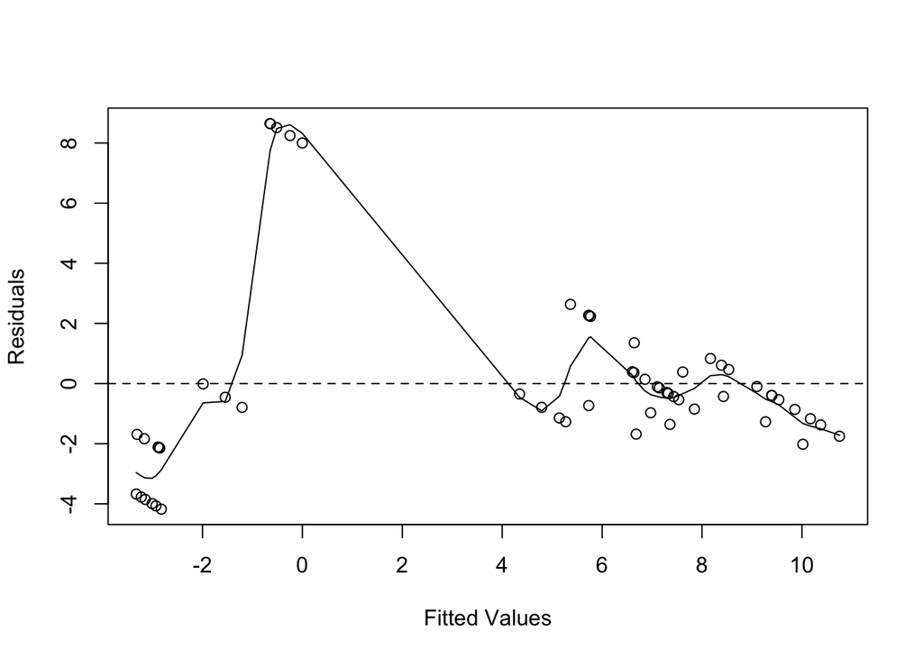

Apparently, the above graph shows that the residuals depend on the explanatory variables, which means that there are country specific effects on the residuals. Violating the assumption of homoscedasticity, this heteroscedasticity is present here as the size of error varies across values of the explanatory variables. Therefore, the coefficients are inefficient and biased. Then, Breusch-Pagan test is used here to make sure whether the country specific effects really exist.

To test the dependancy of residuals on variables, the following equation is utilized to run the BP test:

$$\epsilon = \beta_0 + \beta_1x_{1it} +\beta_2x_{2it}+...+\beta_4x_{4it}$$

The null hypothesis is following:

$$\beta_1 ,\beta_2, \beta_3,\beta_4=0$$

The result is below.

```
##
##  studentized Breusch-Pagan test
##
## data:  L4
## BP = 12.672, df = 4, p-value = 0.01299
```

Clearly, p-value is below 0.05. Therefore, the null hypothesis is rejected and heteroscedasticity is assumed.

Next, these panel specific effects have to be eliminated. To achieve this purpose, the fixed effect model and the random effect model are used, and the following two equations are for these models respectively.

$$polity4 = \alpha_i + \beta_1\log{gdppc}+\beta_2\log{pe}+\beta_3\log{mr}+\beta_4\log{gi} + \epsilon$$
$$polity4 = \beta_0 + \beta_1\log{gdppc}+\beta_2\log{pe}+\beta_3\log{mr}+\beta_4\log{gi}+ \epsilon_i,$$

First of all here, the existence of panel specific effects is tested and investigated. The pFtest is run to test country dependant effects.

```r
pFtest(fixed,pooled)
```

```
##
##  F test for individual effects
##
## data:  demo ~ log(gdppc) + log(pe) + log(mr) + log(gi)
## F = 17.075, df1 = 2, df2 = 50, p-value = 2.228e-06
## alternative hypothesis: significant effects
```

Then, the bptest is conducted.

```
##
##  Lagrange Multiplier Test - (Breusch-Pagan) for unbalanced panels
##
## data:  demo ~ log(gdppc) + log(pe) + log(mr) + log(gi)
## chisq = 0.67568, df = 1, p-value = 0.4111
## alternative hypothesis: significant effects
```

Again, the null hypothesis cannot be rejected and the residuals are not correlated to independent variables.

As results of these above findings, the fixed effect model or the random effect model has to be employed since there are panel specific effects. In order to choose the better model between two, Hausman-test is conducted here.

```
##
##  Hausman Test
##
## data:  demo ~ log(gdppc) + log(pe) + log(mr) + log(gi)
## chisq = 4.6666e-19, df = 4, p-value = 1
## alternative hypothesis: one model is inconsistent
```

## 3. Results: Testing the hypotheses

In regard to the first hypothesis “There is a significant and positive correlation between socioeconomic variables and democracy,” it is partially supported. According to the regression analysis, only two variables (Mortality rate under 5 and Primary education enrollment) have significant and positive effects on the degree of democracy. Although gender inequality is also significant, it shows negative effects on the level of democracy, while GDP per capita is not even statistically significant.

The second hypothesis, which is “Among four socioeconomic variables - GDP, primary education enrollment, gender equality, and child mortality - the educational effect on democracy is the strongest among any other variables,” turns out that it is not true. Rather, the regression output reveals that gender inequality is the strongest explanatory variable on the dependent variable in this case.

The last hypothesis is “The degree of impact of variables on democracy is consistent across selected African countries.” It is also not supported in this current research. Instead, the degree of effects of variables on the level of democracy is very diversified and inconsistent across three countries. In each country, each variable has its specific degree of impact. Moreover, some variables show even opposite effects across countries.

# Conclusion

This present research examined the relationship between socioeconomic status and the level of democracy in selected African countries in order to answer to the question of whether four important socioeconomic variables -namely GDP per capita, primary education enrollment, gender equality in labor force, and child mortality- affect the regime change to democracy. As discussed above, the analyses show that our hypotheses are not entirely supported in three countries: South Africa, Botswana, and Kenya. The first hypothesis, the significant positive effect of socioeconomic development on democracy, cannot be fully proven as GDP per capita is not significant and, interestingly, gender equality has negative effect. While some researches also find that gender equality, an important component of democracy, may have negative effects, it is important to note that the measure of gender equality is not only a complex and disputed concept but also multidimensional that can be measured by different indicators such as educational attainment rates, life expectancy, the percentage of women in the legislature and sex ratios. Therefore, the methodological gap with the data may bring different interpretations.For the second hypothesis, the most impactful factor is the primary education, cannot be fully supported as the analyses show that gender equality is the most significant. For the final hypothesis, we find that the coefficients of explanatory variables have huge differences among countries.

# Acknowledgment

We the authors, Takuma Andoh and Bomi Kim, would like to appreciate Professor Christopher Gandrud, discussants Pol De Santalo and Yumi Komai, and peers in Introduction to Collaborative Social Science Data Analysis for Fall 2016 at the Hertie School of Governance for their time, supports, advices, and guidance.

# Reference

Barro, Robert J. 1999. “Determinants of Democracy.” *Journal of Political Economy*, S6, 107 (December): 158???183.

Bayanpourtehrani, Ghazal, and Kevin Sylwester. 2012. “Democracy and Female Labor Force Participation: An Empirical Examination.” *Social Indicators Research* 112 (3): 749???762. doi:10.1007/s11205-012-0080-2.

Beer, Caroline. 2009. “Democracy and Gender Equality.” *Studies in Comparative International Development* 44 (3): 212???227. doi:10.1007/s12116-009-9043-2.

Boutros-Ghali, Boutros. 1996. “An Agenda for Democratization.” The United Nations.

Dahl, Robert. 2000. “On Democracy.” *Yale University Press*.

Dahl, Robert A. 2010. “Democracy.” *Democracy*. Encyclopedia Britannica. https://www.britannica.com/topic/democracy.

Exponent, The African. 2015. “Sub-Saharan Africa’s Top 10 Most Competitive Economies.” *The African Exponent*. The African Exponent. https://www.africanexponent.com/post/subsaharan-africas-top-10-most-competitive-economies-1025.

“FREEDOM in the World 2016.” 2016. *Freedom House*. Freedom House.

Houweling, T. A. 2005. “Determinants of Under-5 Mortality Among the Poor and the Rich: A Cross-National Analysis of 43 Developing Countries.” *International Journal of Epidemiology* 34 (6): 1257???1265. doi:10.1093/ije/dyi190.

Kekic, Laza. 2007. “The Economist Intelligence Unit?s Index of Democracy.” The Economist Intelligence Unit.

“PolityProject.” n.d. *PolityProject*. Center for Systemic Peace. http://www.systemicpeace.org/polityproject.html.

Samarasinghe, S.W.R. de A. 1994. “Democracy and Democratization in Developing Countries.” The American University; Institute for International Research.

Shandra, John M., Jenna E. Nobles, Bruce London, and John B. Williamson. 2005. “Multinational Corporations, Democracy and Child Mortality: A Quantitative, Cross-National Analysis of Developing Countries.” *Social Indicators Research* 73 (2): 267???293. doi:10.1007/s11205-004-2009-x.

n.d. United Nations Information Services Geneva.